# Simple R (adapted for QRM by TB from John Verzani’s original)

# 1 Introduction

### What is R?

These notes describe how to use R while learning introductory statistics. The purpose is to allow this fine software to be used in ”lower-level” courses where often MINITAB, SPSS, Excel, etc. are used. It is expected that the reader has had at least a pre-calculus course. It is the hope, that students shown how to use R at this early level will better understand the statistical issues and will ultimately benefit from the more sophisticated program despite its steeper “learning curve”.

The benefits of R for an introductory student are

- R is free. R is open-source and runs on UNIX, Windows and Macintosh.
- R has an excellent built-in help system.
- R has excellent graphing capabilities.
- Students can easily migrate to the commercially supported S-Plus program if commercial software is desired.
- R’s language has a powerful, easy to learn syntax with many built-in statistical functions.
- The language is easy to extend with user-written functions.
- R is a computer programming language. For programmers it will feel more familiar than others and for new computer users, the next leap to programming will not be so large.

What is R lacking compared to other software solutions?

- There is no commercial support. (Although one can argue the collaborative support networks at r-help and StackOverflow are better)
- The command language is a programming language so students must learn to appreciate syntax issues etc. R is an open-source (GPL) statistical environment modeled after S and S-Plus

The S language was developed in the late 1980s at AT&T labs. The R project was started by Robert Gentleman and Ross Ihaka of the Statistics Department of the University of Auckland in 1995. It has quickly gained a widespread audience. It is currently maintained by the R core-development team, a hard-working, international team of volunteer developers. The R project web page http://www.r-project.org is the main site for information on R. At this site are directions for obtaining the software, accompanying packages and other sources of documentation.

# 2 First steps

Visit (https://cran.r-project.org/), download and install R. Then visit (https://www.rstudio.com/products/rstudio/download/), download and install rstudio desktop. Then start up rstudio. You should see a screen like this

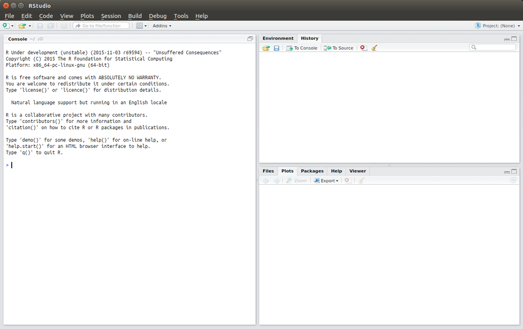

At this point you can type R commands directly into the R console (on the left side of the screen). However the recommended way of working is to type your commands into a file, which you can save for later reference and use. To work this way, your first step should be to choose File -> New File -> R script. After this you will see the left of the screen is now split into two sections with the File window at the top and the R console at the bottom - as per this picture:

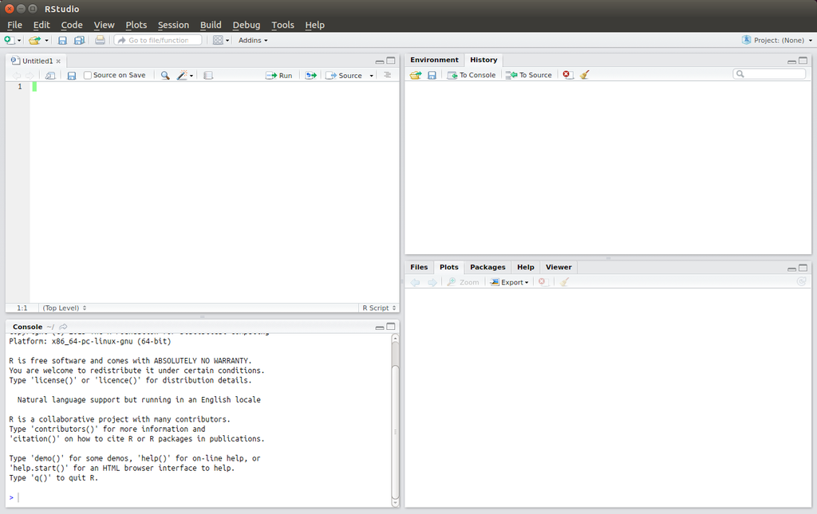

The commands you type in the file window can be executed either by pressing Control-Enter on the line(s) you want to execute, or highlighting the lines and clicking the ‘Run’ button.

In the remainder of this document, R commands appear in grey boxes, and you should follow this tutorial by typing and running these commands in your file window. The output of commands is shown in a white text box.

# 3 Data

Statistics is the study of data. After learning how to start R, the first thing we need to be able to do is learn how to enter data into R and how to manipulate the data once there.

### Entering data with c

The most useful R command for quickly entering in small data sets is the c function. This function combines, or concatenates terms together. As an example, suppose we have the following count of the number of typos per page of these notes:

2 3 0 3 1 0 0 1

To enter this into an R session we do so by typing the following two lines (in the highlit box below) into the file window (don’t forget to press Control-Enter after doing so). You will see the commands echoed in the console window, together with any output.

```r
typos <- c(2,3,0,3,1,0,0,1)
typos
```

```
## [1] 2 3 0 3 1 0 0 1
```

Notice a few things

- We assigned the values to a variable called typos
- The assignment operator is a <- but, alternatively, the ‘equals sign’ = can also be used, but most people prefer to use the former.
- The value of the typos doesn’t automatically print out. It does when we type just the name though as the last input line indicates
- The value of typos is prefaced with a funny looking [1]. This indicates that the value is a vector. More on that later.

### Typing less

For many implementations of R you can save yourself a lot of typing if you learn that the arrow keys can be used to retrieve your previous commands. In particular, each command is stored in a history and the up arrow will traverse backwards along this history and the down arrow forwards. The left and right arrow keys will work as expected. This combined with a mouse can make it quite easy to do simple editing of your previous commands.

### Applying a function

R comes with many built in functions that one can apply to data such as typos. One of them is the mean function for finding the mean or average of the data. To use it is easy

```r
 mean(typos)
```

```
## [1] 1.25
```

As well, we could call the median, or var to find the median or sample variance. The syntax is the same – the function name followed by parentheses to contain the argument(s):

```r
median(typos)
```

```
## [1] 1
```

```r
var(typos)
```

```
## [1] 1.642857
```

### Data is a vector

The data is stored in R as a vector. This means simply that it keeps track of the order that the data is entered in. In particular there is a first element, a second element up to a last element. This is a good thing for several reasons:

- Our simple data vector typos has a natural order – page 1, page 2 etc. We wouldn’t want to mix these up.
- We would like to be able to make changes to the data item by item instead of having to enter in the entire data set again.
- Vectors are also a mathematical object. There are natural extensions of mathematical concepts such as addition and multiplication that make it easy to work with data when they are vectors.

Let’s see how these apply to our typos example. First, suppose these are the typos for the first draft of section 1 of these notes. We might want to keep track of our various drafts as the typos change. This could be done by the following:

```r
td1 <-  c(2,3,0,3,1,0,0,1)
td2 <-  c(0,3,0,3,1,0,0,1)
```

That is, the two typos on the first page were fixed. Notice the two different variable names.

Now, you might say, that is a lot of work to type in the data a second time. Can’t I just tell R to change the first page? The answer of course is “yes”. Here is one way

```r
td1 <-  c(2,3,0,3,1,0,0,1)
td2 <-  td1 # make a copy
td2[1] <-  0 # assign the first page 0 typos
```

Now notice a few things. First, the comment character, #, is used to make comments. Basically anything after the comment character is ignored by R. As you are following this tutorial, you do not need to type these comments, but it is good practice for later reference, for yourself and for other readers, to get in the habit of commenting your work. Second, the assignment to the first entry in the vector td2 is done by referencing the first entry in the vector. This is done with square brackets []. It is important to keep this in mind: parentheses () are for functions, and square brackets [] are for vectors (and also other data structures). In particular, we have the following values currently in td2

```r
td2 # print out the value
```

```
## [1] 0 3 0 3 1 0 0 1
```

```r
 td2[2] # print 2nd pages’ value
```

```
## [1] 3
```

```r
td2[4] # 4th page
```

```
## [1] 3
```

```r
td2[-4] # all but the 4th page
```

```
## [1] 0 3 0 1 0 0 1
```

```r
td2[c(1,2,3)] # fancy, print 1st, 2nd and 3rd.
```

```
## [1] 0 3 0
```

Notice negative indices give everything except these indices. The last example is very important. You can take more than one value at a time by using another vector of index numbers. This is called slicing. Okay, we need to work these notes into shape, let’s find the really bad pages. By inspection, we can notice that pages 2 and 4 are a problem. Can we do this with R in a more systematic manner?

We can, so let’s explore how using some new functions. First, max()

```r
max(td2) # what are worst pages?
```

```
## [1] 3
```

```r
td2 == 3 # Where are they?
```

```
## [1] FALSE  TRUE FALSE  TRUE FALSE FALSE FALSE FALSE
```

Notice, the usage of double equals signs (==). This tests all the values of td2 to see if they are equal to 3. The 2nd and 4th answer yes (TRUE) the others no. Think of this as asking R a question. Is the value equal to 3? R answers this for each element at once with a long vector of TRUE’s and FALSE’s. Now the question is – how can we get the indices (pages) corresponding to the TRUE values? Let’s rephrase: which indices have exactly 3 typos? If you guessed that the command which() will work, you are on your way to R mastery:

```r
which(td2 == 3)
```

```
## [1] 2 4
```

We could have acheived this without which() - there are always many ways to do the same thing. The basic idea is to create a new vector 1 2 3 … keeping track of the page numbers, and then slicing off just the ones for which td2==3, like this:

```r
n = length(td2) # how many pages
pages = 1:n # how we get the page numbers
pages # pages is simply 1 to number of pages
```

```
## [1] 1 2 3 4 5 6 7 8
```

```r
pages[td2 == 3] # logical extraction. Very useful
```

```
## [1] 2 4
```

To create the vector 1 2 3 … we used the simple : colon operator. We could have typed this in, but this is quicker so a useful thing to know. The command a:b is simply a, a+1, a+2, …, b if a,b are integers and intuitively defined if not. A more general R function is seq() which is a bit more typing. Try ?seq to see it’s options. To produce the above try seq(a,b,1), using approprate values for a and b.

The use of extracting elements of a vector using another vector of the same size which is comprised of TRUEs and FALSEs is referred to as extraction by a logical vector. Notice this is different from extracting by page numbers by slicing as we did before. Knowing how to use slicing and logical vectors gives you the ability to easily access your data as you desire. Of course, we could have done all the above at once with this command (but why?)

```r
(1:length(td2))[td2 == max(td2)]
```

```
## [1] 2 4
```

This looks awful and is prone to typos and confusion, but does illustrate how things can be combined into short powerful statements. This is an important point. To appreciate the use of R you need to understand how one composes the output of one function or operation with the input of another. In mathematics we call this composition.

Finally, we might want to know how many typos we have, or how many pages still have typos to fix or what the difference is between drafts? These can all be answered with mathematical functions. For these three questions we have

```r
sum(td2) # How many typos?
```

```
## [1] 8
```

```r
sum(td2>0) # How many pages with typos?
```

```
## [1] 4
```

```r
td1 - td2 # difference between the two
```

```
## [1] 2 0 0 0 0 0 0 0
```

#### Example: Keeping track of a stock; adding to the data

Suppose the daily closing price of your favorite stock for two weeks is 45,43,46,48,51,46,50,47,46,45 We can again keep track of this with R using a vector:

```r
x <-  c(45,43,46,48,51,46,50,47,46,45)
mean(x) # the mean
```

```
## [1] 46.7
```

```r
median(x) # the median
```

```
## [1] 46
```

```r
max(x) # the maximum or largest value
```

```
## [1] 51
```

```r
min(x) # the minimum value
```

```
## [1] 43
```

This illustrates that many interesting functions can be found easily. Let’s see how we can do some others. First, lets add the next two weeks worth of data to x. Suppose the new data was 48,49,51,50,49,41,40,38,35,40 We can add this several ways, but the easiest is to use the c() function to combine the new data with the original.

```r
new <- c(48,49,51,50,49,41,40,38,35,40)
x <- c(x, new) # append values to x
length(x) # how long is x now (it was 10)
```

```
## [1] 20
```

```r
x # check data has been appended
```

```
##  [1] 45 43 46 48 51 46 50 47 46 45 48 49 51 50 49 41 40 38 35 40
```

Before we leave this example, lets see how we can do some other functions of the data. Here are a few examples. The moving average simply means to average over some previous number of days. Suppose we want the 5 day moving average (50-day or 100-day is more often used). Here is one way to do so. We can do this for days 5 through 20 as the other days don’t have enough data.

```r
day <- 5;
mean(x[day:(day+4)])
```

```
## [1] 48
```

The trick is the slice takes out days 5,6,7,8,9

```r
day:(day+4)
```

```
## [1] 5 6 7 8 9
```

and the mean takes just those values of x. What is the maximum value of the stock? This is easy to answer with max(x). However, you may be interested in a running maximum or the largest value to date. This too is easy – if you know that R had a built-in function to handle this. It is called cummax which will take the cumulative maximum. Here is the result for our 4 weeks worth of data along with the similar cummin:

```r
cummax(x) # running maximum
```

```
##  [1] 45 45 46 48 51 51 51 51 51 51 51 51 51 51 51 51 51 51 51 51
```

```r
cummin(x) # running minimum
```

```
##  [1] 45 43 43 43 43 43 43 43 43 43 43 43 43 43 43 41 40 38 35 35
```

#### Example: Working with mathematics

R makes it easy to translate mathematics in a natural way once your data is read in. For example, suppose the yearly number of whales beached in Texas during the period 2000 to 2009 is 74 122 235 111 292 111 211 133 156 79 What is the mean, the variance, the standard deviation? Again, R makes these easy to answer:

```r
whale <- c(74, 122, 235, 111, 292, 111, 211, 133, 156, 79)
mean(whale)
```

```
## [1] 152.4
```

```r
var(whale)
```

```
## [1] 5113.378
```

```r
std(whale)
```

```
## Error in std(whale): could not find function "std"
```

```r
sqrt(var(whale))
```

```
## [1] 71.50789
```

```r
sqrt(sum((whale - mean(whale))^2 /(length(whale) - 1)))
```

```
## [1] 71.50789
```

Notice the $\Sigma$ is now sum, $\bar{x}$ is mean(whale) and length(x) is used instead of $n$. Of course, it might be nice to have this available as a built-in function. Since this example is so easy, lets see how - type the following over three lines as shown:

```r
std <-  function(x){
  sqrt(var(x))
}
```

Now we have created the function, we can use it just like any other R function:

```r
std(whale)
```

```
## [1] 71.50789
```

The ease of defining your own functions is a very appealing feature of R we will return to. Finally, if we had thought a little harder we might have found the actual built-in sd() command. Which gives

```r
sd(whale)
```

```
## [1] 71.50789
```

#### R Basics: Accessing Data

There are several ways to extract data from a vector. Here is a summary using both slicing and extraction by a logical vector. Suppose x is the data vector, for example x=1:10. Try out the following: (NB The text in red is a remark, and not for typing into R)

[output not shown]

#### Problems

```r
miles <-  c(65311, 65624, 65908, 66219, 66499, 66821, 67145, 67447)
x <-  diff(miles)
```

You should see the number of miles between fill-ups. Use the max to find the maximum number of miles between fill-ups, the mean function to find the average number of miles and the min to get the minimum number of miles.

2. Suppose you track your commute times for two weeks (10 days) and you find the following times in minutes 17 16 20 24 22 15 21 15 17 22 Enter this into R. Use the function max to find the longest commute time, the function mean to find the average and the function min to find the minimum. Oops, the 24 was a mistake. It should have been 18. How can you fix this? Do so, and then find the new average. How many times was your commute 20 minutes or more? To answer this one can try (if you called your numbers commutes)

```r
sum(commutes >= 20)
```

What do you get? What percent of your commutes are less than 17 minutes? How can you answer this with R?

3. Your cell phone bill varies from month to month. Suppose your year has the following monthly amounts 46 33 39 37 46 30 48 32 49 35 30 48 Enter this data into a variable called bill. Use the sum command to find the amount you spent this year on the cell phone. What is the smallest amount you spent in a month? What is the largest? How many months was the amount greater than $40? What percentage was this?
4. You want to buy a used car and find that over 3 months of watching the classifieds you see the following prices (suppose the cars are all similar) 9000 9500 9400 9400 10000 9500 10300 10200 Use R to find the average value and compare it to Edmund’s (http://www.edmunds.com) estimate of $9500. Use R to find the minimum value and the maximum value. Which price would you like to pay?
5. Try to guess the results of these R commands. Remember, the way to access entries in a vector is with []. Suppose we assume

```r
x = c(1,3,5,7,9)
y = c(2,3,5,7,11,13)
```

- x+1
- y*2
- length(x)
- length(y)
- x + y
- sum(x>5) and sum(x[x>5])
- sum(x>5 | x< 3) # read | as ’or’, & and ’and’
- y[3]
- y[-3]
- y[x] #(What is NA?)
- y[y>=7]
6. Let the data x be given by

```r
x = c(1, 8, 2, 6, 3, 8, 5, 5, 5, 5)
```

# 4 Univariate Data

There is a distinction between types of data in statistics and R knows about some of these differences. In particular, initially, data can be of three basic types: categorical, discrete numeric and continuous numeric. Methods for viewing and summarizing the data depend on the type, and so we need to be aware of how each is handled and what we can do with it.

Categorical data is data that records categories. Examples could be, a survey that records whether a person is for or against a proposition. Or, a police force might keep track of the race of the individuals they pull over on the highway. The U.S. census (http://www.census.gov), which takes place every 10 years, asks several different questions of a categorical nature. Again, there was one on race which in the year 2000 included 15 categories with write-in space for 3 more for this variable (you could mark yourself as multi-racial). Another example, might be a doctor’s chart which records data on a patient. The gender or the history of illnesses might be treated as categories.

Continuing the doctor example, the age of a person and their weight are numeric quantities. The age is a discrete numeric quantity (typically) and the weight as well (most people don’t say they are 4.673 years old). These numbers are usually reported as integers. If one really needed to know precisely, then they could in theory take on a continuum of values, and we would consider them to be continuous. Why the distinction? In data sets, and some tests it is important to know if the data can have ties (two or more data points with the same value). For discrete data it is true, for continuous data, it is generally not true that there can be ties.

A simple, intuitive way to keep track of these is to ask what is the mean (average)? If it doesn’t make sense then the data is categorical (such as the average of a non-smoker and a smoker), if it makes sense, but might not be an answer (such as 18.5 for age when you only record integers integer) then the data is discrete otherwise it is likely to be continuous.

### Categorical data

We often view categorical data with tables but we may also look at the data graphically with bar graphs or pie charts.

#### Using tables

The table command allows us to look at tables. Its simplest usage looks like table(x) where x is a categorical variable.

##### Example: Smoking survey

A survey asks people if they smoke or not. The data is Yes, No, No, Yes, Yes We can enter this into R with the c() command, and summarize with the table command as follows

```r
x <- c("Yes","No","No","Yes","Yes")
table(x)
```

```
## x
##  No Yes
##   2   3
```

The table command simply adds up the frequency of each unique value of the data.

#### Factors

Categorical data is often used to classify data into various levels or factors. For example, the smoking data could be part of a broader survey on student health issues. R has a special class for working with factors which is occasionally important to know as R will automatically adapt itself when it knows it has a factor. To make a factor is easy with the command factor or as.factor. Notice the difference in how R treats factors with this example

```r
x <- c("Yes","No","No","Yes","Yes")
x # print out values in x
```

```
## [1] "Yes" "No"  "No"  "Yes" "Yes"
```

```r
factor(x) # print out value in factor(x)
```

```
## [1] Yes No  No  Yes Yes
## Levels: No Yes
```

#### Bar charts

A bar chart draws a bar with a a height proportional to the count in the table. The height could be given by the frequency, or the proportion. The graph will look the same, but the scales may be different. Suppose, a group of 25 people are surveyed as to their beer-drinking preference. The categories were (1) Domestic can, (2) Domestic bottle, (3) Microbrew and (4) import. The raw data is 3 4 1 1 3 4 3 3 1 3 2 1 2 1 2 3 2 3 1 1 1 1 4 3 1 Let’s make a barplot of both frequencies and proportions. First, we create the data then we plot (figure 1)

```r
beer <- c(3, 4, 1, 1, 3, 4, 3, 3, 1, 3, 2, 1, 2, 1, 2, 3, 2, 3, 1, 1, 1, 1, 4, 3, 1)
```

```r
table(beer) # see categories and frequencies
```

```
## beer
##  1  2  3  4
## 10  4  8  3
```

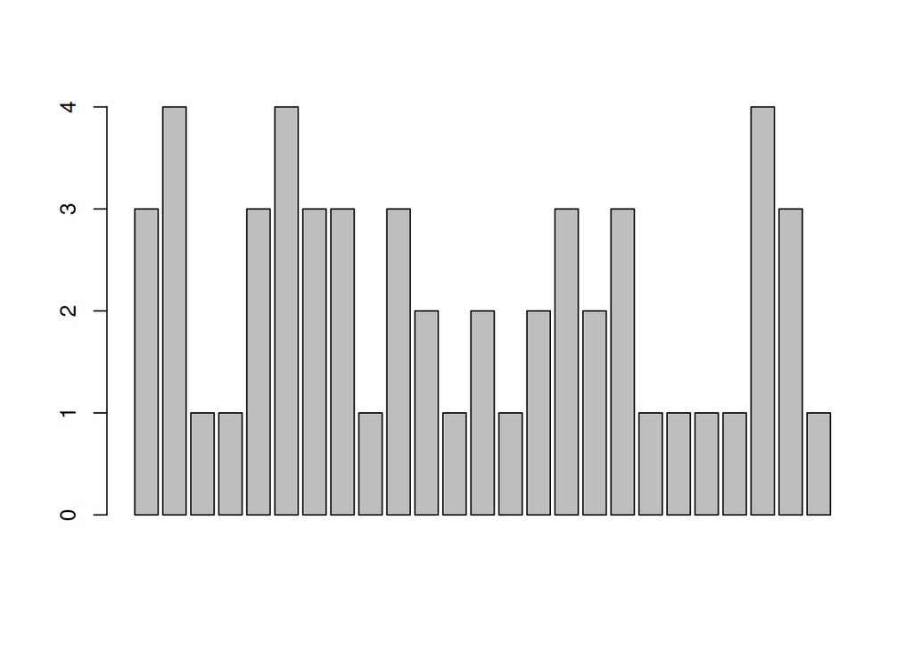

```r
barplot(beer) # this isn’t correct
```

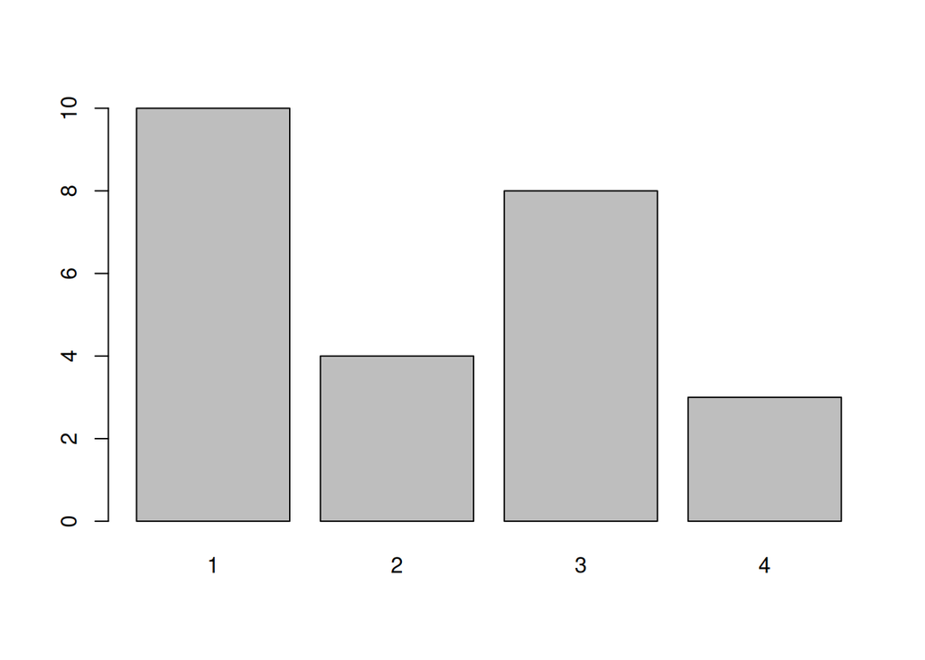

```r
barplot(table(beer)) # Yes, call with summarized data
```

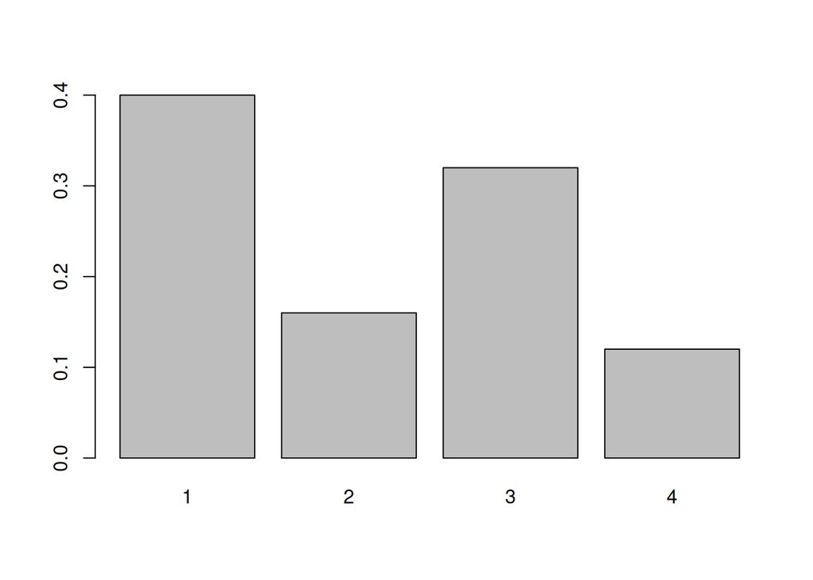

```r
barplot(table(beer)/length(beer)) # divide by n for proportion
```

Figure 1: Sample barplots

Notice a few things:

- We could have used scan() to read in the data via typing at the keyboard. This command can be very useful for reading data from a file or by typing. Try ?scan for more information, but the basic usage is simple. You type in the data. It stops adding data when you enter a blank row. Try uing scan to enter the beer data.
- The color scheme is kinda ugly.
- We did 3 barplots. The first to show that we don’t use barplot with the raw data.
- The second shows the use of the table command to create summarized data, and the result of this is sent to barplot creating the barplot of frequencies shown.
- Finally, the command

```r
table(beer)/length(beer)
```

```
## beer
##    1    2    3    4
## 0.40 0.16 0.32 0.12
```

produces the proportions first. (We divided by the number of data points which is 25 or length(beer).) The result is then handed off to barplot to make a graph. Notice it has the same shape as the previous one, but the height axis is now between 0 and 1 as it measures the proportion and not the frequency.

#### Pie charts

The same data can be studied with pie charts using the pie function.23 Here are some simple examples illustrating the usage (similar to barplot(), but with some added features.

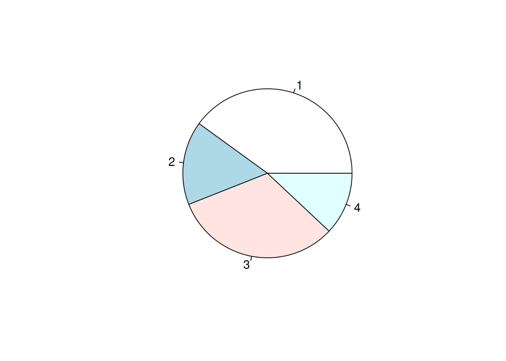

```r
beer.counts <- table(beer) # store the table result
pie(beer.counts) # first pie -- kind of dull
```

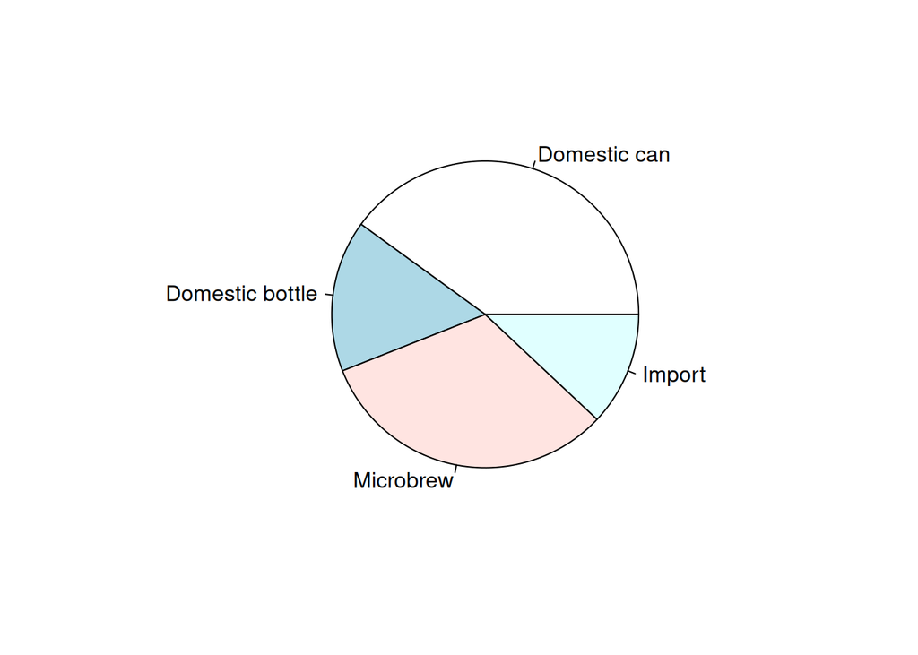

```r
names(beer.counts) <-  c("Domestic can","Domestic bottle", "Microbrew","Import") # give names
pie(beer.counts) # prints out names
```

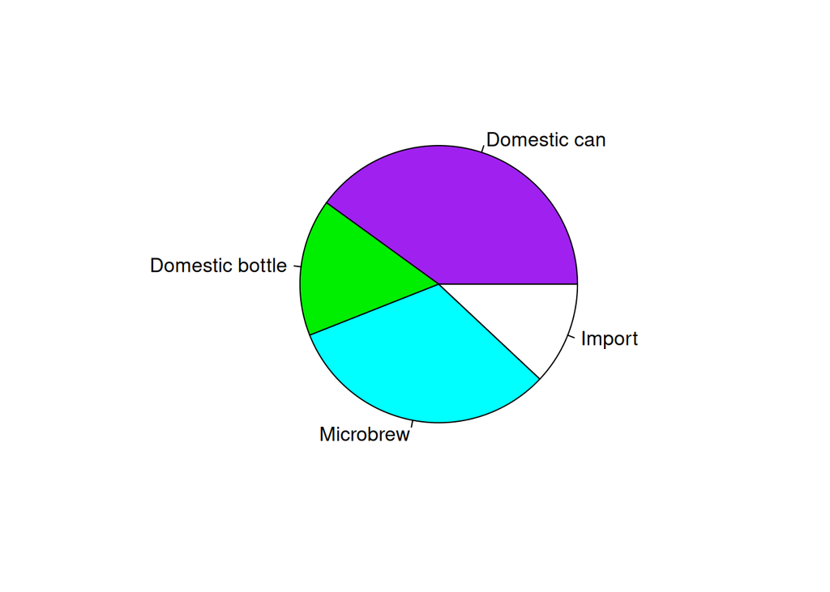

```r
pie(beer.counts,col=c("purple","green2","cyan","white")) # now with colors
```

The first one was kind of boring so we added names. This is done with the names() function which allows us to specify names to the categories. The resulting piechart shows how the names are used. Finally, we added color to the piechart. This is done by setting the piechart attribute col. We set this equal to a vector of color names that was the same length as our beer.counts. The help command (?pie) gives some examples for automatically getting different colors, notably using rainbow and gray. Notice we used additional arguments to the function pie The syntax for these is name=value. The ability to pass in named values to a function, makes it easy to have fewer functions as each one can have more functionality.

### Numerical data

There are many options for viewing numerical data. First, we consider the common numerical summaries of center and spread.

#### Numeric measures of center and spread

To describe a distribution we often want to know where is it centered and what is the spread. These are typically measured with mean and variance (or standard deviation), or the median and more generally the five-number summary. The R commands for these are mean, var, sd, median, fivenum and summary.

##### Example: CEO salaries

Suppose, CEO yearly compensations are sampled and the following are found (in millions). (This is before being indicted for cooking the books.) 12 .4 5 2 50 8 3 1 4 0.25

```r
sals <-  c(12, .4, 5, 2, 50, 8, 3, 1, 4, 0.25)
mean(sals) # the average
```

```
## [1] 8.565
```

```r
var(sals) # the variance
```

```
## [1] 225.5145
```

```r
sd(sals) # the standard deviation
```

```
## [1] 15.01714
```

```r
median(sals) # the median
```

```
## [1] 3.5
```

```r
fivenum(sals) # min, lower hinge, Median, upper hinge, max
```

```
## [1]  0.25  1.00  3.50  8.00 50.00
```

```r
summary(sals)
```

```
##    Min. 1st Qu.  Median    Mean 3rd Qu.    Max.
##   0.250   1.250   3.500   8.565   7.250  50.000
```

##### Some Extra Insight: The difference between fivenum and the quantiles:

You may have noticed the slight difference between the fivenum and the summary command. In particular, one gives 1.00 for the lower hinge and the other 1.250 for the first quantile. What is the difference? The story is below.

The median is the point in the data that splits it into half. That is, half the data is above the data and half is below. For example, if our data in sorted order is 10, 17, 18, 25, 28 then the midway number is clearly 18 as 2 values are less and 2 are more. Whereas, if the data had an additional point: 10, 17, 18, 25, 28, 28 Then the midway point is somewhere between 18 and 25 as 3 are larger and 3 are smaller. For concreteness, we average the two values giving 21.5 for the median. Notice, the point where the data is split in half depends on the number of data points. If there are an odd number, then this point is the (n + 1)/2 largest data point. If there is an even number of data points, then again we use the (n + 1)/2 data point, but since this is a fractional number, we average the actual data to the left and the right.

The idea of a quantile generalizes this median. The p quantile, (also known as the 100p%-percentile) is the point in the data where 100p% is less, and 100(1-p)% is larger. If there are n data points, then the p quantile occurs at the position 1+(n-1)p with weighted averaging if this is between integers. For example the .25 quantile of the numbers 10,17,18,25,28,28 occurs at the position 1+(6-1)(.25) = 2.25. That is 1/4 of the way between the second and third number which in this example is 17.25.

The .25 and .75 quantiles are denoted the quartiles. The first quartile is called Q1, and the third quartile is called Q3. (You’d think the second quartile would be called Q2, but use “the median” instead.) These values are in the R function RCodesummary. More generally, there is a quantile function which will compute any quantile between 0 and 1. To find the quantiles mentioned above we can do

```r
data=c(10, 17, 18, 25, 28, 28)
summary(data)
```

```
##    Min. 1st Qu.  Median    Mean 3rd Qu.    Max.
##   10.00   17.25   21.50   21.00   27.25   28.00
```

```r
quantile(data,.25)
```

```
##   25%
## 17.25
```

```r
quantile(data,c(.25,.75)) # two values of p at once
```

```
##   25%   75%
## 17.25 27.25
```

There is a historically popular set of alternatives to the quartiles, called the hinges that are somewhat easier to compute by hand. The median is defined as above. The lower hinge is then the median of all the data to the left of the median, not counting this particular data point (if it is one.) The upper hinge is similarly defined. For example, if your data is again 10, 17, 18, 25, 28, 28, then the median is 21.5, and the lower hinge is the median of 10, 17, 18 (which is 17) and the upper hinge is the median of 25,28,28 which is 28. These are available in the function fivenum(), and later appear in the boxplot function. Here is an illustration with the sals data, which has n = 10. From above we should have the median at (10+1)/2=5.5, the lower hinge at the 3rd value and the upper hinge at the 8th largest value. Whereas, the value of Q1 should be at the 1 + (10 - 1)(1/4) = 3.25 value. We can check that this is the case by sorting the data

```r
sort(sals)
```

```
##  [1]  0.25  0.40  1.00  2.00  3.00  4.00  5.00  8.00 12.00 50.00
```

```r
fivenum(sals) # note 1 is the 3rd value, 8 the 8th.
```

```
## [1]  0.25  1.00  3.50  8.00 50.00
```

```r
summary(sals) # note 3.25 value is 1/4 way between 1 and 2
```

```
##    Min. 1st Qu.  Median    Mean 3rd Qu.    Max.
##   0.250   1.250   3.500   8.565   7.250  50.000
```

#### Resistant (aka Robust) measures of center and spread

The most used measures of center and spread are the mean and standard deviation due to their relationship with the normal distribution, but they suffer when the data has long tails, or many outliers. Various measures of center and spread have been developed to handle this. The median is just such a resistant measure. It is oblivious to a few arbitrarily large values. That is, is you make a measurement mistake and get 1,000,000 for the largest value instead of 10 the median will be indifferent.

Other resistant measures are available. A common one for the center is the trimmed mean. This is useful if the data has many outliers (like the CEO compensation, although better if the data is symmetric). We trim off a certain percentage of the data from the top and the bottom and then take the average. To do this in R we need to tell the mean() how much to trim.

```r
mean(sals, trim=1/10) # trim 1/10 off top and bottom
```

```
## [1] 4.425
```

```r
mean(sals, trim=2/10)
```

```
## [1] 3.833333
```

Notice as we trim more and more, the value of the mean gets closer to the median which is when trim=1/2. Again notice how we used a named argument to the mean function.

The variance and standard deviation are also sensitive to outliers. Resistant measures of spread include the IQR and the mad.

The IQR or interquartile range is the difference of the 3rd and 1st quartile. The function IQR calculates it for us

```r
IQR(sals)
```

```
## [1] 6
```

The median average deviation (MAD) is also a useful, resistant measure of spread. It finds the median of the absolute differences from the median and then multiplies by a constant. (Huh?) Here is a formula median|Xi - median(X)|(1.4826) That is, find the median, then find all the differences from the median. Take the absolute value and then find the median of this new set of data. Finally, multiply by the constant. It is easier to do with R than to describe.

```r
mad(sals)
```

```
## [1] 4.15128
```

And to see that we could do this ourself, we would do

```r
median(abs(sals - median(sals))) # without normalizing constant
```

```
## [1] 2.8
```

```r
median(abs(sals - median(sals))) * 1.4826
```

```
## [1] 4.15128
```

(The choice of 1.4826 makes the value comparable with the standard deviation for the normal distribution.)

#### Stem-and-leaf Charts

There are a range of graphical summaries of data. If the data set is relatively small, the stem-and-leaf diagram is very useful for seeing the shape of the distribution and the values. It takes a little getting used to. The number on the left of the bar is the stem, the number on the right the digit. You put them together to find the observation. Suppose you have the box score of a basketball game and find the following points per game for players on both teams 2 3 16 23 14 12 4 13 2 0 0 0 6 28 31 14 4 8 2 5 To create a stem and leaf chart is simple

```r
scores <- c(2, 3, 16, 23, 14, 12, 4, 13, 2, 0, 0, 0, 6, 28, 31, 14, 4, 8, 2, 5)
apropos("stem") # What exactly is the name?
```

```
## [1] "R_system_version" "stem"             "system"           "system.file"
## [5] "system.time"      "system2"
```

```r
stem(scores)
```

```
##
##   The decimal point is 1 digit(s) to the right of the |
##
##   0 | 000222344568
##   1 | 23446
##   2 | 38
##   3 | 1
```

Notice we use apropos() to help find the name for the function. It is stem() and not stemleaf(). The apropos() command is convenient when you think you know the function’s name but aren’t sure. The help command will help us find help on the given function or dataset once we know the name. For example help(stem) or the abbreviated ?stem will display the documentation on the stem function. Suppose we wanted to break up the categories into groups of 5. We can do so by setting the “scale”

```r
stem(scores,scale=2)
```

```
##
##   The decimal point is 1 digit(s) to the right of the |
##
##   0 | 000222344
##   0 | 568
##   1 | 2344
##   1 | 6
##   2 | 3
##   2 | 8
##   3 | 1
```

#### Example: Making numeric data categorical

Categorical variables can come from numeric variables by aggregating values. For example. The salaries could be placed into broad categories of 0-1 million, 1-5 million and over 5 million. To do this using R one uses the cut() function and the table() function. Suppose the salaries are again 12 .4 5 2 50 8 3 1 4 .25 And we want to break that data into the intervals [0, 1],(1, 5],(5, 50] To use the cut command, we need to specify the cut points. In this case 0,1,5 and 50 (=max(sals)). Here is the syntax

```r
sals <- c(12, .4, 5, 2, 50, 8, 3, 1, 4, .25) # enter data
cats <-  cut(sals,breaks=c(0,1,5,max(sals))) # specify the breaks
cats # view the values
```

```
##  [1] (5,50] (0,1]  (1,5]  (1,5]  (5,50] (5,50] (1,5]  (0,1]  (1,5]  (0,1]
## Levels: (0,1] (1,5] (5,50]
```

```r
table(cats) # organize
```

```
## cats
##  (0,1]  (1,5] (5,50]
##      3      4      3
```

```r
levels(cats) = c("poor","rich","rolling in it") # change labels
table(cats)
```

```
## cats
##          poor          rich rolling in it
##             3             4             3
```

```r
cats
```

```
##  [1] rolling in it poor          rich          rich          rolling in it
##  [6] rolling in it rich          poor          rich          poor
## Levels: poor rich rolling in it
```

Notice, cut() answers the question “which interval is the number in?”. The output is the interval (as a factor). This is why the table command is used to summarize the result of cut. Additionally, the names of the levels where changed as an illustration of how to manipulate these.

#### Histograms

If there is too much data, or your audience doesn’t know how to read the stem-and-leaf, you might try other summaries. The most common is similar to the bar plot and is a histogram. The histogram defines a sequence of breaks and then counts the number of observation in the bins formed by the breaks. (This is identical to the features of the cut() function.) It plots these with a bar similar to the bar chart, but the bars are touching. The height can be the frequencies, or the proportions. In the latter case the areas sum to 1 – a property that will be sound familiar when you study probability distributions. In either case the area is proportional to probability.

29.6 28.2 19.6 13.7 13.0 7.8 3.4 2.0 1.9 1.0 0.7 0.4 0.4 0.3  
0.3 0.3 0.3 0.3 0.2 0.2 0.2 0.1 0.1 0.1 0.1 0.1

Let’s visualize it (figure 3). First we scan it in then make some histograms

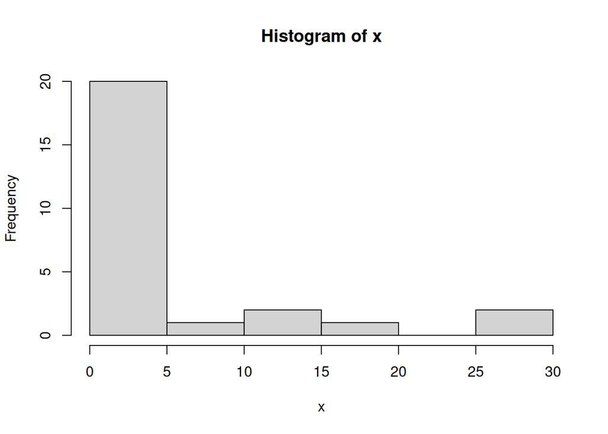

```r
x <- c(29.6, 28.2, 19.6, 13.7 ,13.0, 7.8, 3.4, 2.0, 1.9, 1.0, 0.7, 0.4, 0.4, 0.3, 0.3,
 0.3, 0.3, 0.3, 0.2, 0.2, 0.2, 0.1, 0.1, 0.1, 0.1, 0.1)
hist(x) # frequencies
```

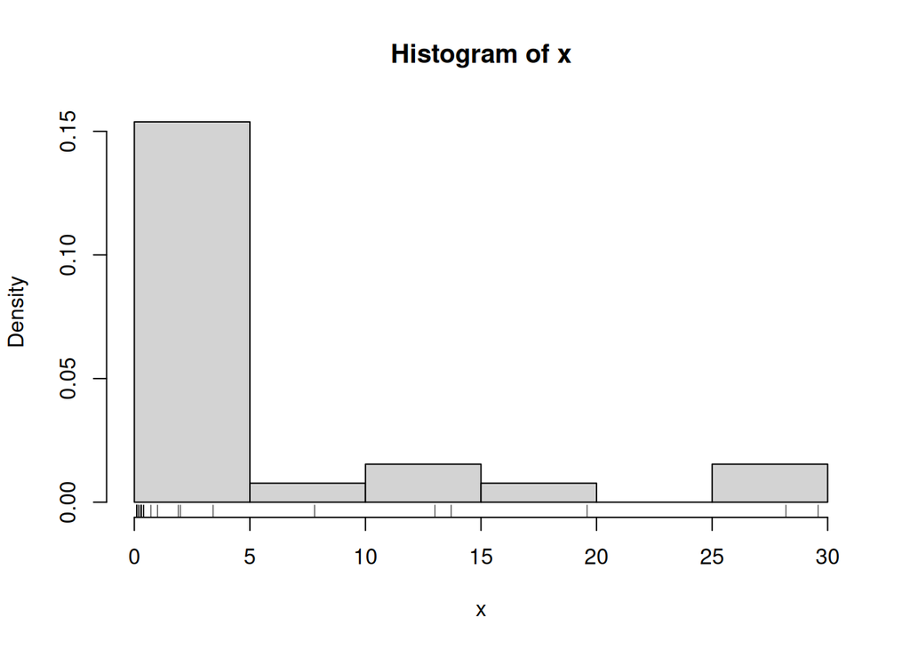

```r
hist(x,probability=TRUE) # proportions (or probabilities)
rug(jitter(x)) # add tick marks
```

Figure 3: Histograms using frequencies and proportions

Two graphs are shown. The first is the default graph which makes a histogram of frequencies (total counts). The second does a histogram of proportions which makes the total area add to 1. This is preferred as it relates better to the concept of a probability density. Note the only difference is the scale on the y axis. A nice addition to the histogram is to plot the points using the rug command. It was used above in the second graph to give the tick marks just above the x-axis. If your data is discrete and has ties, then the rug(jitter(x)) command will give a little jitter to the x values to eliminate ties.

Notice these commands opened up a graph window. The graph window in R has few options available using the mouse, but many using command line options.

The basic histogram has a predefined set of break points for the bins. If you want, you can specify the number of breaks or your own break points (figure 4).

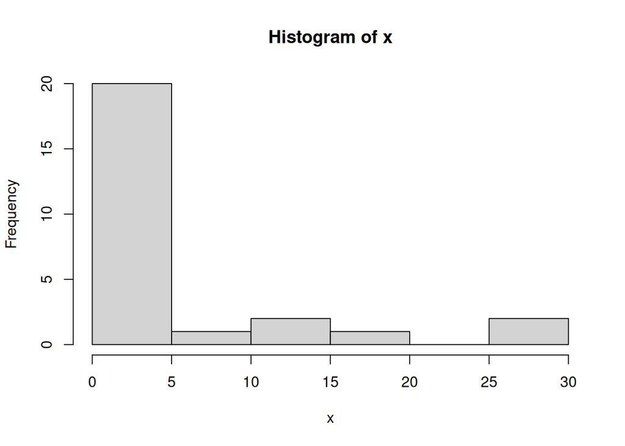

```r
hist(x,breaks=10) # 10 breaks, or just hist(x,10)
```

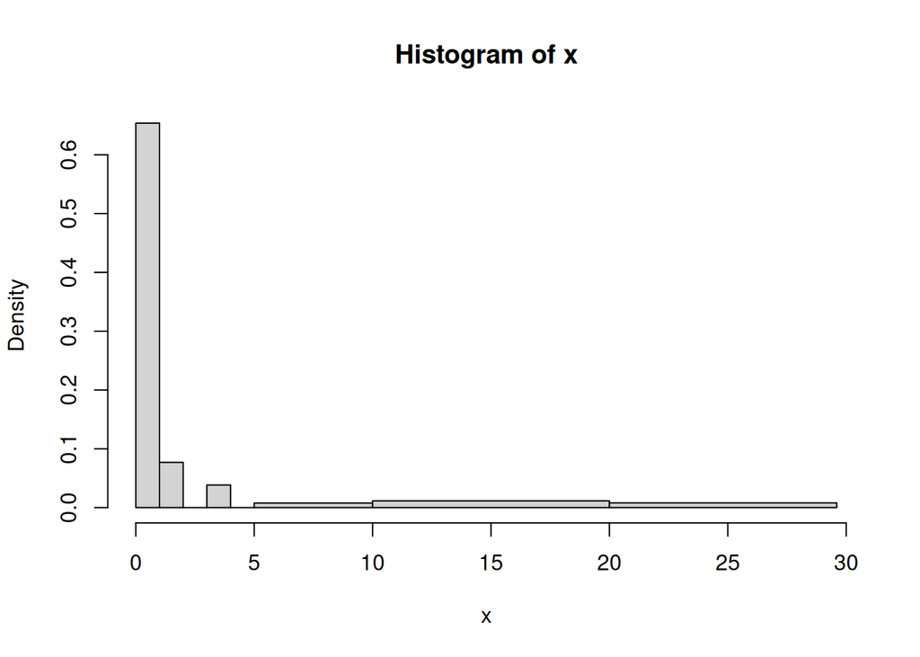

```r
hist(x,breaks=c(0,1,2,3,4,5,10,20,max(x))) # specify break points
```

Figure 4: Histograms with breakpoints specified

From the histogram, you can easily make guesses as to the values of the mean, the median, and the IQR. To do so, you need to know that the median divides the histogram into two equal area pieces, the mean would be the point where the histogram would balance if you tried to, and the IQR captures exactly the middle half of the data.

#### Boxplots

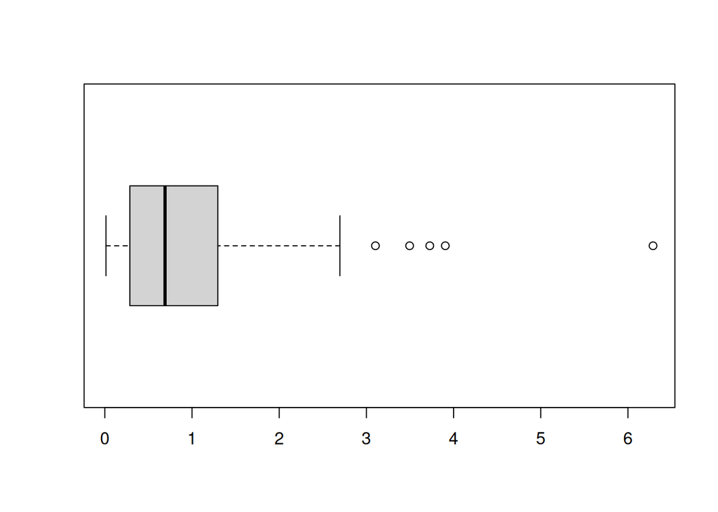

Figure 5: A typical boxplot

The boxplot (eg. figure 5) is used to summarize data succinctly, quickly displaying if the data is symmetric or has suspected outliers. It is based on the 5-number summary. In its simplest usage, the boxplot has a box with lines at the lower hinge (basically Q1), the Median, the upper hinge (basically Q3) and whiskers which extend to the min and max. To showcase possible outliers, a convention is adopted to shorten the whiskers to a length of 1.5 times the box length. Any points beyond that are plotted with points. These may further be marked differently if the data is more than 3 box lengths away. Thus the boxplots allows us to check quickly for symmetry (the shape looks unbalanced) and outliers (lots of data points beyond the whiskers). In figure 5 we see a skewed distribution with a long tail.

#### Example: Movie sales, reading in a dataset

First, check which folder on your computer is currently set as R’s working directory, by typing this command

```r
getwd()
```

Then, download the movies data file from using

```r
download.file("https://raw.githubusercontent.com/liztwb/files/refs/heads/main/movies.csv", dest = "movies.csv")
```

Finally, issue this following command. This will read the data from the file, and store the data in the data frame named ‘movies’

```r
movies <- read.csv('movies.csv')
```

We now have the data stored in a data frame called movies.

```r
movies
```

```
##     X                          title current previous gross
## 1   1 Pearl Harbor (TO)                 29.6     75.2 118.9
## 2   2 Shrek (DW)                        28.2     55.2 148.4
## 3   3 The Animal (CO)                   19.6       NA  19.6
## 4   4 Moulin Rouge (20)                 13.7      0.3  14.4
## 5   5 What's the Worst that... (MGM)    13.0       NA  13.0
## 6   6 The Mummy Returns (UN)             7.8     19.0 181.2
## 7   7 A Knight's Tale (CO)               3.4      9.1  49.4
## 8   8 Bridget Jones's Diary (MM)         2.0      4.2  65.4
## 9   9 Angel Eyes (WB)                    1.9      6.2  21.7
## 10 10 Momento (Newmarket Films)          1.0      1.9  15.8
## 11 11 Along Came a Spider (PA)           0.7      2.1  71.8
## 12 12 Spy Kids (DI)                      0.4      1.3 105.9
## 13 13 Blow (NL)                          0.4      1.3  52.2
## 14 14 Driven (WB)                        0.3      1.2  31.8
## 15 15 O'Brother, Where Art... (TS)       0.3      0.3  44.2
## 16 16 Crocodile Dundee in L.A. (PA)      0.3      1.0  24.3
## 17 17 The Tailor of Panama (CO)          0.3      0.7  12.9
## 18 18 Crouching Tiger...Dragon (SC)      0.3      0.5 127.2
## 19 19 Save the Last Dance (PA)           0.2      0.5  90.2
## 20 20 The Golden Bowl (LG)               0.2      0.5   1.5
## 21 21 With a Friend Like Harry (MM)      0.2      0.4   1.8
## 22 22 Traffic (USA)                      0.1      0.4 123.8
## 23 23 Castaway (20)                      0.1      0.2 233.2
## 24 24 Startup.com (AR)                   0.1      0.2   0.5
## 25 25 Amores Perros (Lions Gate)         0.1      0.3   4.8
## 26 26 Kingdom Come (FS)                  0.1      0.4  22.7
```

```r
names(movies)
```

```
## [1] "X"        "title"    "current"  "previous" "gross"
```

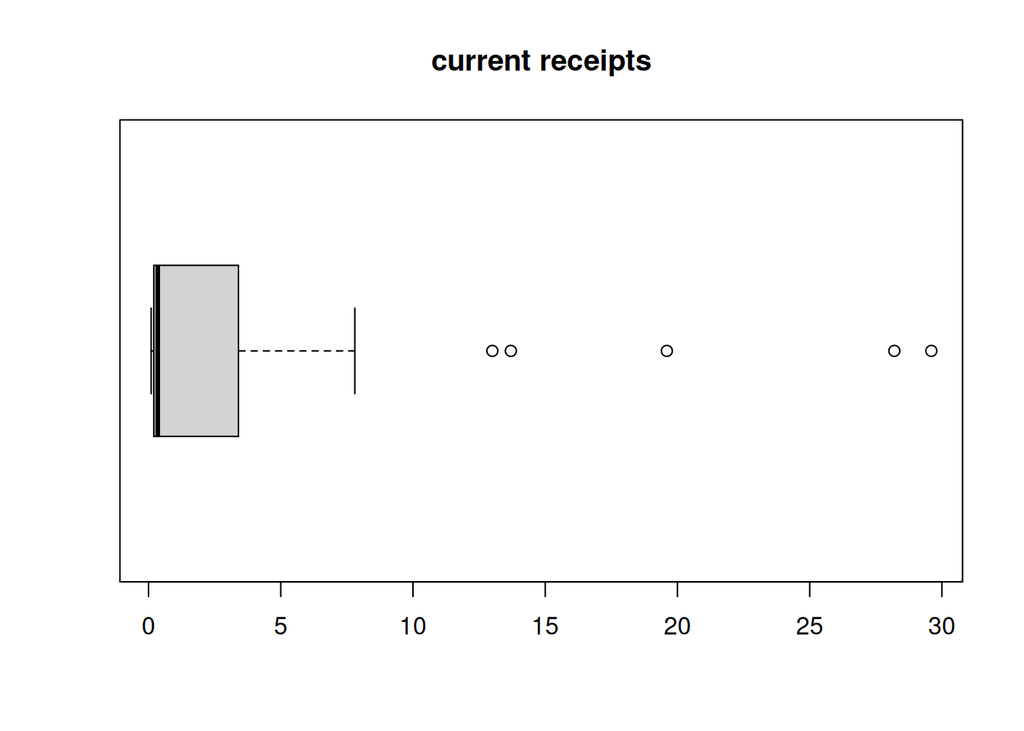

```r
## first we want to plot the current week's takings
## we can access the 'current' column of the data frame via movies$current
boxplot(movies$current, main="current receipts", horizontal=TRUE)
```

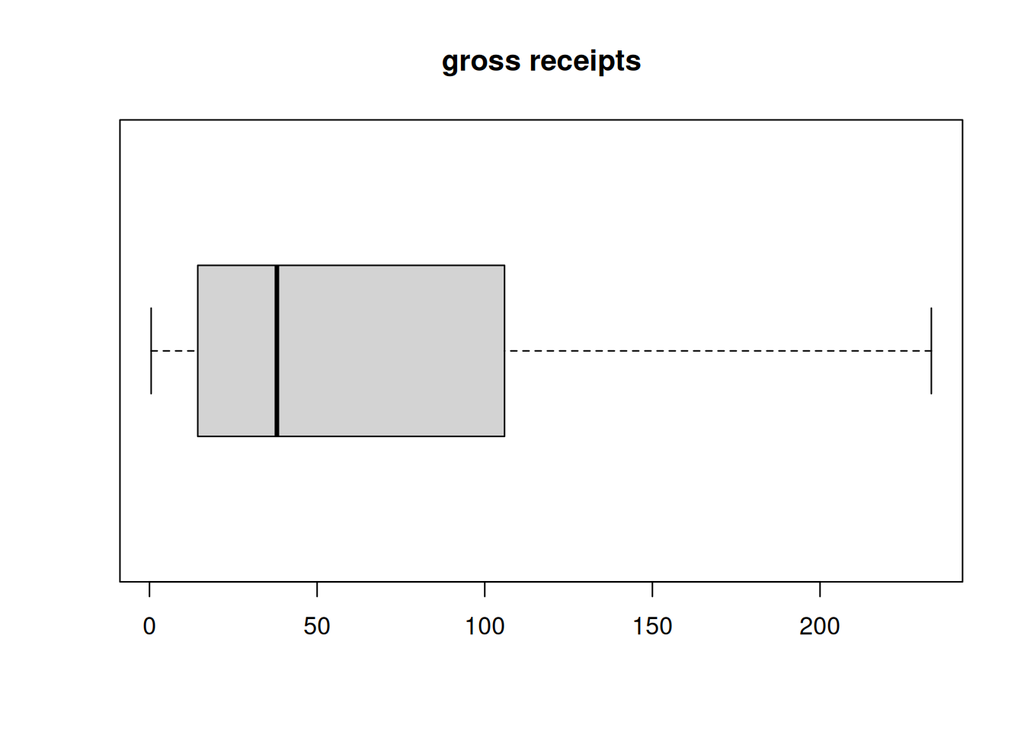

```r
## similarly for the 'gross' receipts
boxplot(movies$gross, main="gross receipts", horizontal=TRUE)
```

Figure 6 - movies boxplots

We plot both the current sales and the gross sales in a boxplot (figure 6). Notice, both distributions are skewed, but the gross sales are less so. This shows why Hollywood is so interested in the “big hit”, as a real big hit can generate a lot more revenue than quite a few medium sized hits.

#### R Basics: Reading in datasets with library and data

```r
library('datasets') # load the library
data("lynx") # load the data
lynx
```

```
## Time Series:
## Start = 1821
## End = 1934
## Frequency = 1
##   [1]  269  321  585  871 1475 2821 3928 5943 4950 2577  523   98  184  279  409
##  [16] 2285 2685 3409 1824  409  151   45   68  213  546 1033 2129 2536  957  361
##  [31]  377  225  360  731 1638 2725 2871 2119  684  299  236  245  552 1623 3311
##  [46] 6721 4254  687  255  473  358  784 1594 1676 2251 1426  756  299  201  229
##  [61]  469  736 2042 2811 4431 2511  389   73   39   49   59  188  377 1292 4031
##  [76] 3495  587  105  153  387  758 1307 3465 6991 6313 3794 1836  345  382  808
##  [91] 1388 2713 3800 3091 2985 3790  674   81   80  108  229  399 1132 2432 3574
## [106] 2935 1537  529  485  662 1000 1590 2657 3396
```

```r
summary(lynx) # Just what is lynx?
```

```
##    Min. 1st Qu.  Median    Mean 3rd Qu.    Max.
##    39.0   348.2   771.0  1538.0  2566.8  6991.0
```

The library and data commands can be usied in several different ways:

- To list all available packages Use the command library().
- To list all available datasets Use the command data() without any arguments
- To list all data sets in a given package Use data(package=’package name’) for example data(package=datasets).
- To read in a dataset Use data(’dataset name’). As in the example data(lynx). You first need to load the package to access its datasets as in the command library(datasets).
- To find out information about a dataset. You can use the help command to see if there is documentation on the data set. For example help(“lynx”) or equivalently ?lynx.

### Frequency Polygons

Some times you will see the histogram information presented in a different way. Rather than draw a rectangle for each bin, put a point at the top of the rectangle and then connect these points with straight lines. This is called the frequency polygon. To generate it, we need to know the bins, and the heights. Here is a way to do so with R getting the necessary values from the hist command. Suppose the data is batting averages for the New York Yankees 6

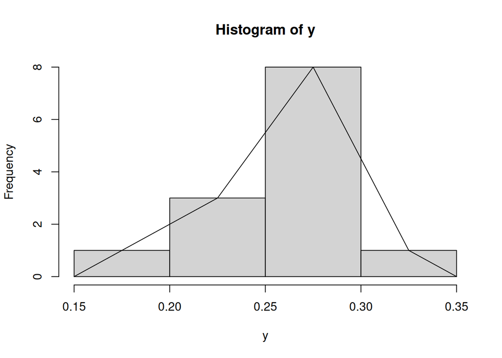

```r
y = c(.314,.289,.282,.279,.275,.267,.266,.265,.256,.250,.249,.211,.161)
tmp = hist(y) # store the results
lines(c(min(tmp$breaks), tmp$mids,max(tmp$breaks)), c(0,tmp$counts,0), type="l") ##add lines
```

Figure 8: Histogram with frequency polygon

Ughh, this is just too much to type, so we could write a function to do this

```r
simple.freqpoly <- function(x){
  tmp<-hist(x, probability=FALSE)
  lines(c(min(tmp$breaks), tmp$mids,max(tmp$breaks)), c(0,tmp$counts,0), type="l")
}
```

We can then use this so:

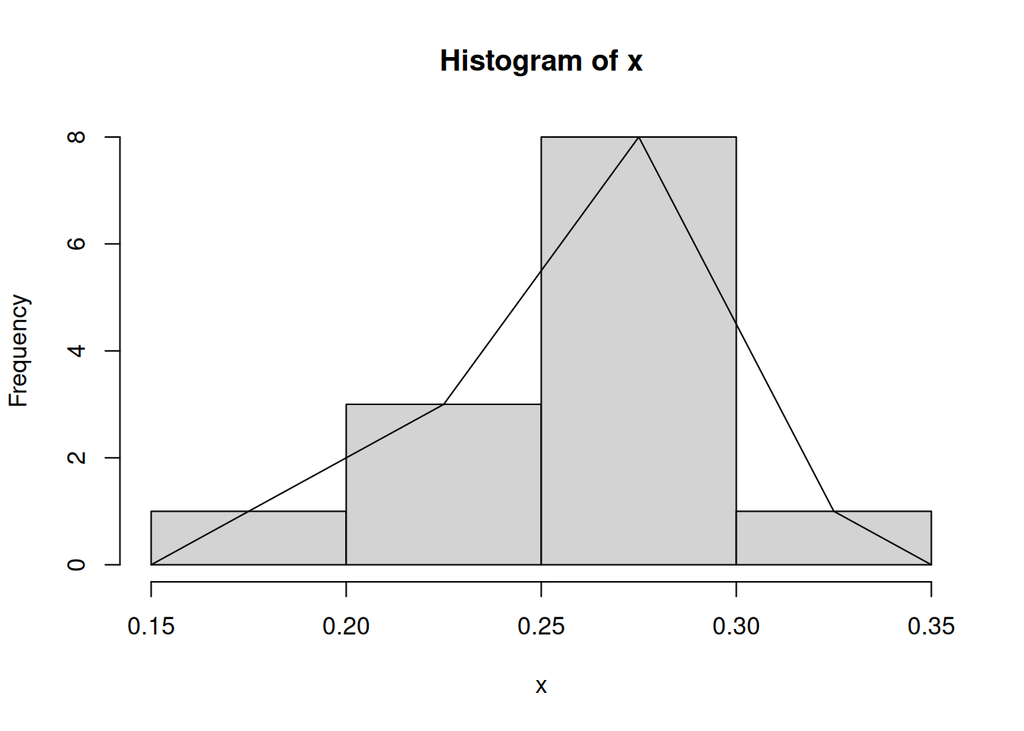

```r
simple.freqpoly(y)
```

Notice though that the basic information was available to us with the values stored in tmp, labeled breaks and counts.

### Densities

The R command density can be used to give more sophisticated attempts to view the data with a curve (as the frequency polygon does). The density() function has means to do automatic selection of bandwidth. See the help page for the full description. If we use the default choice it is easy to add a density plot to a histogram. We just call the lines function with the result from density (or plot if it is the first graph). For instance:

```r
data(faithful)
head(faithful)
```

```
##   eruptions waiting
## 1     3.600      79
## 2     1.800      54
## 3     3.333      74
## 4     2.283      62
## 5     4.533      85
## 6     2.883      55
```

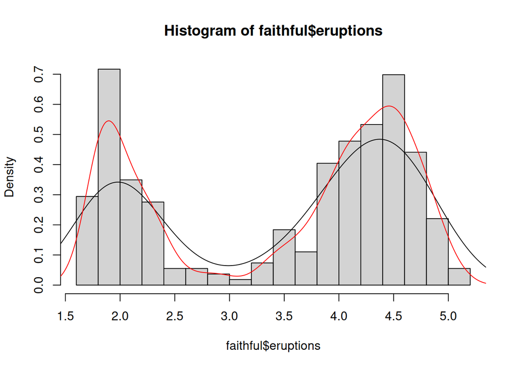

```r
hist(faithful$eruptions, 15, prob=TRUE) # proportions, not frequencies
lines(density(faithful$eruptions)) # lines makes a curve, default bandwidth
lines(density(faithful$eruptions,bw="SJ"), col='red') # Use SJ bandwidth, in red
```

Figure 9: Histogram and density estimates. Notice choice of bandwidth is very important.

#### Problems

1. Enter in the data 60 85 72 59 37 75 93 7 98 63 41 90 5 17 97 Make a stem and leaf plot.
2. Read this stem and leaf plot, enter in the data and make a histogram: The decimal point is 1 digit(s) to the right of the |  
   8 | 028  
   9 | 115578  
   10 | 1669  
   11 | 01
3. One can generate random data with the “r”-commands. For example

```r
x = rnorm(100)
```

produces 100 random numbers with a normal distribution. Create two different histograms for two different times of defining x as above. Do you get the same histogram?

4. Run the command

```r
source('https://raw.githubusercontent.com/liztwb/files/refs/heads/main/uvd.R')
```

Afterwards, you should see some new datasets have been created in your workspace.

Make a histogram and boxplot of the following data sets: south, crime (in each of 1983 and 1993) and aid. Which of these data sets is skewed? Which has outliers, which is symmetric.

5. For the data sets bumpers, firstchi, math make a histogram. Try to predict the mean, median and standard deviation. Check your guesses with the appropriate R commands.
6. The number of O-ring failures for the first 23 flights of the US space shuttle Challenger were 0 1 0 NA 0 0 0 0 0 1 1 1 0 0 3 0 0 0 0 0 2 0 1 (NA means not available – the equipment was lost). Make a table of the possible categories. Try to find the mean. (You might need to try mean(x,na.rm=TRUE) to avoid the value NA, or look at x[!is.na(x)].)
7. The dataset pi2000 contains the first 2000 digits of $\pi$. Make a histogram. Is it surprising? Next, find the proportion of 1’s, 2’s and 3’s. Can you do it for all 10 digits 0-9?
8. Fit a density estimate to the dataset pi2000 .

# 5 Bivariate Data

The relationship between 2 variables is often of interest. For example, are height and weight related? Are age and heart rate related? Are income and taxes paid related? Is a new drug better than an old drug? Does a batter hit better as a switch hitter or not? Does the weather depend on the previous days weather? Exploring and summarizing such relationships is the current goal.

### Handling bivariate categorical data

The table command will summarize bivariate data in a similar manner as it summarized univariate data. Suppose a student survey is done to evaluate if students who smoke study less. The data recorded is

| Person ID | Smokes | amount of Studying |
| --- | --- | --- |
| 1 | Y | less than 5 hours |
| 2 | N | 5 - 10 hours |
| 3 | N | 5 - 10 hours |
| 4 | Y | more than 10 hours |
| 5 | N | more than 10 hours |
| 6 | Y | less than 5 hours |
| 7 | Y | 5 - 10 hours |
| 8 | Y | less than 5 hours |
| 9 | N | more than 5 hours |
| 10 | Y | 5 - 10 hours |

We can handle this in R by creating two vectors to hold our data, and then using the table command.

```r
smokes <- c("Y","N","N","Y","N","Y","Y","Y","N","Y")
amount <-  c(1,2,2,3,3,1,2,1,3,2)
table(smokes,amount)
```

```
##       amount
## smokes 1 2 3
##      N 0 2 2
##      Y 3 2 1
```

We see that there may be some relationship7 What would be nice to have are the marginal totals and the proportions. For example, what proportion of smokers study 5 hours or less. We know that this is 3 /(3+2+1) = 1/2, but how can we do this in R? The command prop.table will compute this for us. It needs to be told the table to work on, and a number to indicate if you want the row proportions (a 1) or the column proportions (a 2) the default is to just find proportions.

```r
tmp <- table(smokes,amount) # store the table
prop.table(tmp,1) # the rows sum to 1 now
```

```
##       amount
## smokes         1         2         3
##      N 0.0000000 0.5000000 0.5000000
##      Y 0.5000000 0.3333333 0.1666667
```

```r
prop.table(tmp,2) # the columns sum to 1 now
```

```
##       amount
## smokes         1         2         3
##      N 0.0000000 0.5000000 0.6666667
##      Y 1.0000000 0.5000000 0.3333333
```

```r
prop.table(tmp)
```

```
##       amount
## smokes   1   2   3
##      N 0.0 0.2 0.2
##      Y 0.3 0.2 0.1
```

If we don’t lile the number of digits displyes, we can always use the round funcion. Eg

```r
round(prop.table(tmp,2), 3) # 3 decimal places
```

```
##       amount
## smokes     1     2     3
##      N 0.000 0.500 0.667
##      Y 1.000 0.500 0.333
```

### Plotting tabular data

You might wish to graphically represent the data summarized in a table. For the smoking example, you could plot the amount variable for each of No or Yes, or the No and Yes variable for each level of smoking. In either case, you can use a barplot. We simply call it in the appropriate manner.

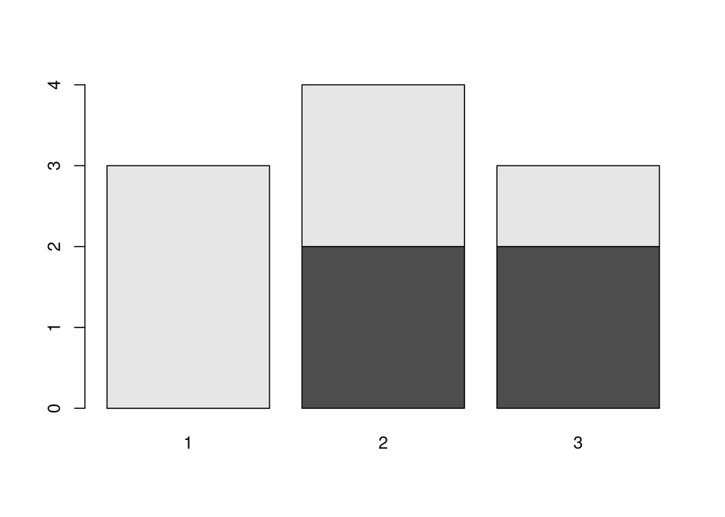

```r
 barplot(table(smokes,amount))
```

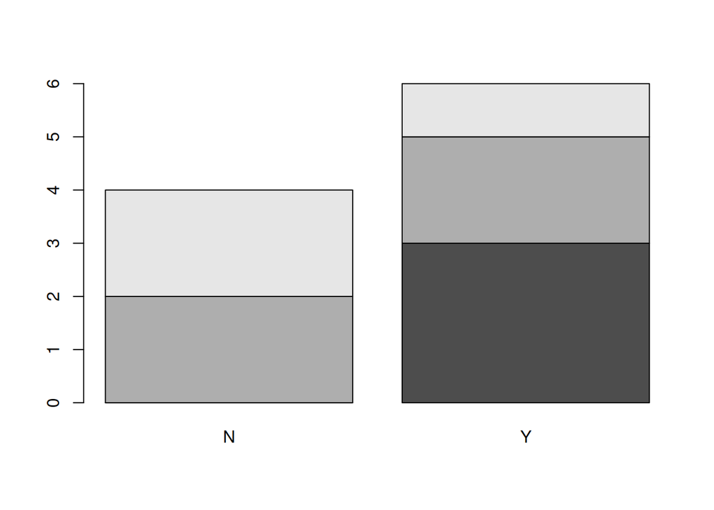

```r
barplot(table(amount,smokes))
```

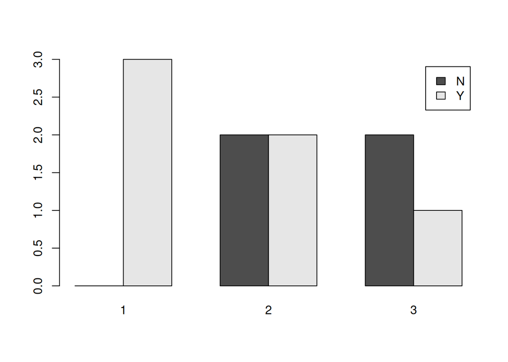

```r
smokes=factor(smokes) # for names
barplot(table(smokes,amount), beside=TRUE, # put beside not stacked
 legend.text=TRUE) # add legend
```

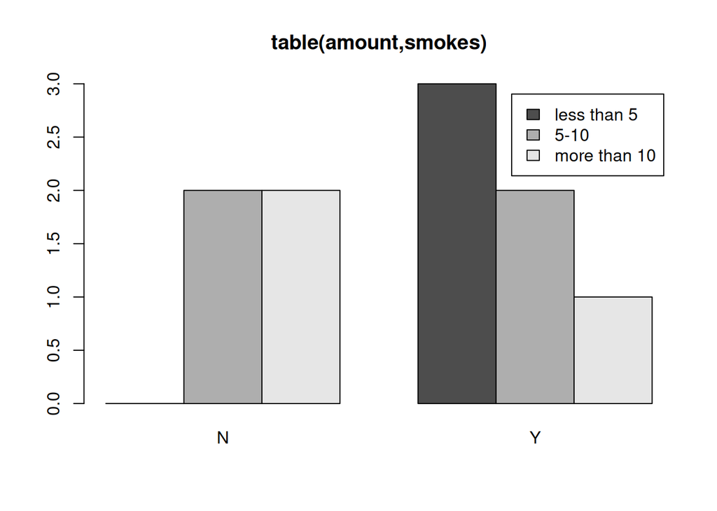

```r
barplot(table(amount,smokes),main="table(amount,smokes)", beside=TRUE,
 legend.text=c("less than 5","5-10","more than 10"))
```

Figure 9: 4 barplots of same data

#### Some Extra Insight: Conditional proportions

You may also want to know about the conditional proportions. For example, among the smokers what are the proportions. To answer this, we need to divide the second row by 6. One or two rows is easy to do by hand, but how do we automate the work? The function apply will apply a function to rows or columns of a matrix. In this case, we need a function to find the proportions of a vector. This is as easy as

```r
prop = function(x) x/sum(x)
```

To apply this function to the matrix x is easy. First the columns (index 2) are done by

```r
apply(x, 2, prop)
```

Index 1 is for the rows, however, we need to use the transpose function, t() to make the result look right.

```r
t(apply(x, 1, prop))
```

### Handling bivariate data: categorical vs. numerical

Suppose you have numerical data for several categories. A simple example might be in a drug test, where you have data (in suitable units) for an experimental group and for a control group.

experimental: 5 5 5 13 7 11 11 9 8 9  
control: 11 8 4 5 9 5 10 5 4 10  
You can summarize the data separately and compare, but how can you view the data together? A side by side boxplot is a good place to start. To generate one is simple:

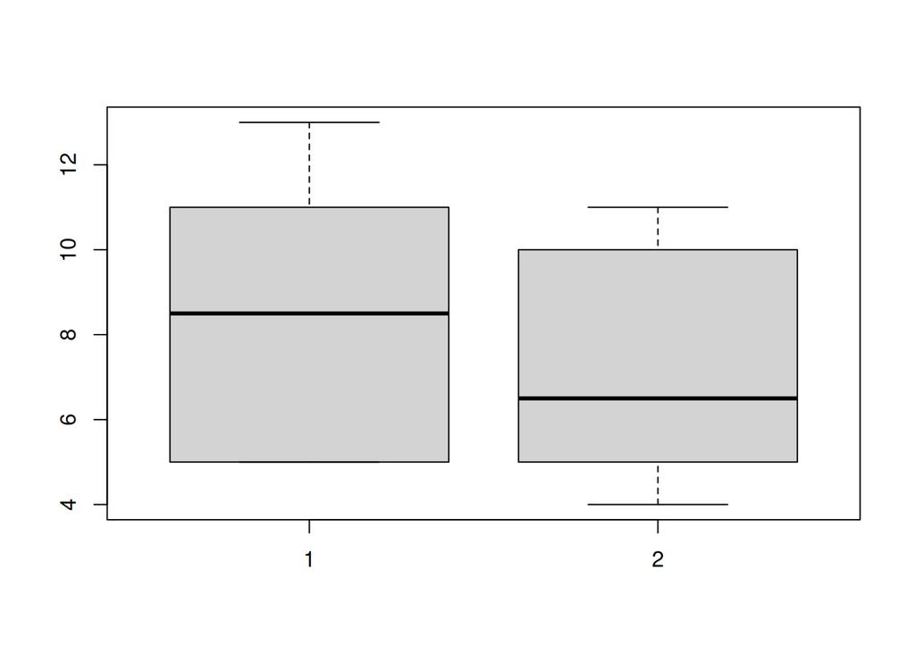

```r
x <- c(5, 5, 5, 13, 7, 11, 11, 9, 8, 9)
y <- c(11, 8, 4, 5, 9, 5, 10, 5, 4, 10)
boxplot(x,y)
```

Figure 11: Side-by-side boxplots

From this comparison (figure 11), we see that the y variable (the control group, labeled 2 on the graph) seems to be less than that of the x variable (the experimental group).

Of course, you may also receive this data in terms of the numbers and a variable indicating the category as follows  
amount: 5 5 5 13 7 11 11 9 8 9 11 8 4 5 9 5 10 5 4 10  
category: 1 1 1 1 1 1 1 1 1 1 2 2 2 2 2 2 2 2 2 2  
To make a side by side boxplot is still easy, but only if you use the ‘formula’ syntax as follows

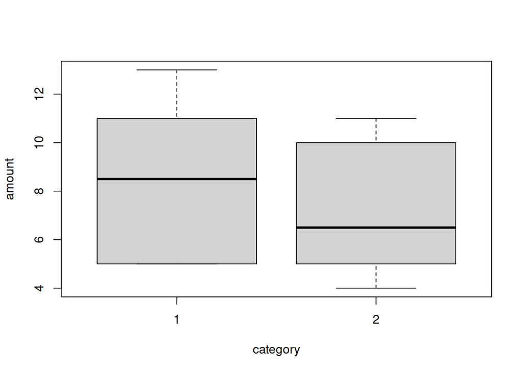

```r
amount <- c(5, 5, 5, 13, 7, 11, 11, 9, 8, 9, 11, 8, 4, 5, 9, 5, 10, 5, 4, 10)
category <- c(1, 1, 1, 1, 1, 1, 1, 1, 1, 1, 2, 2, 2, 2, 2, 2, 2, 2, 2, 2)
boxplot(amount ~ category) # note the tilde ~
```

Read the part amount ~ category as breaking up the values in amount, by the categories in category and displaying each one. Verbally, you might read this as “amount by category”. More on this syntax will appear in the section on multivariate data.

### Bivariate data: numerical vs. numerical

Comparing two numerical variables can be done in different ways. If the two variables are thought to be independent samples you might like to compare their distributions in some manner. However, if you expect a relationship between the variables, you might like to look for that by plotting pairs of points.

#### Comparing two distributions with plots

If we wish to compare two distributions, we can do so with side-by-side boxplots, However, we may wish to compare histograms or some other graphs to see more of the data. Here are several different ways to do so. Side by side boxplots with rug By using the rug command we can see all the data. It works best with smallish data sets (otherwise use the jitter command to break ties).

Let’s read in a new dataset

```r
source('https://raw.githubusercontent.com/liztwb/files/refs/heads/main/homedata.R')
head(homedata) # just look at first 6 rows
```

```
##    y1970  y2000
## 1  89700 359100
## 2 118400 504500
## 3 116400 477300
## 4 122000 500400
## 5  91500 433900
## 6 102800 464800
```

```r
summary(homedata) # statistacl summary of each variable
```

```
##      y1970            y2000
##  Min.   :     0   Min.   :   7400
##  1st Qu.: 57000   1st Qu.: 161400
##  Median : 68900   Median : 251700
##  Mean   : 70821   Mean   : 268370
##  3rd Qu.: 80500   3rd Qu.: 335600
##  Max.   :297200   Max.   :1182800
```

```r
h <- homedata #make copy just to save typing!
```

Each row represent the assessed value of a particular house. The first valuation was performed in 1970, the second in 2000. We would expect to see a positive association between the two.

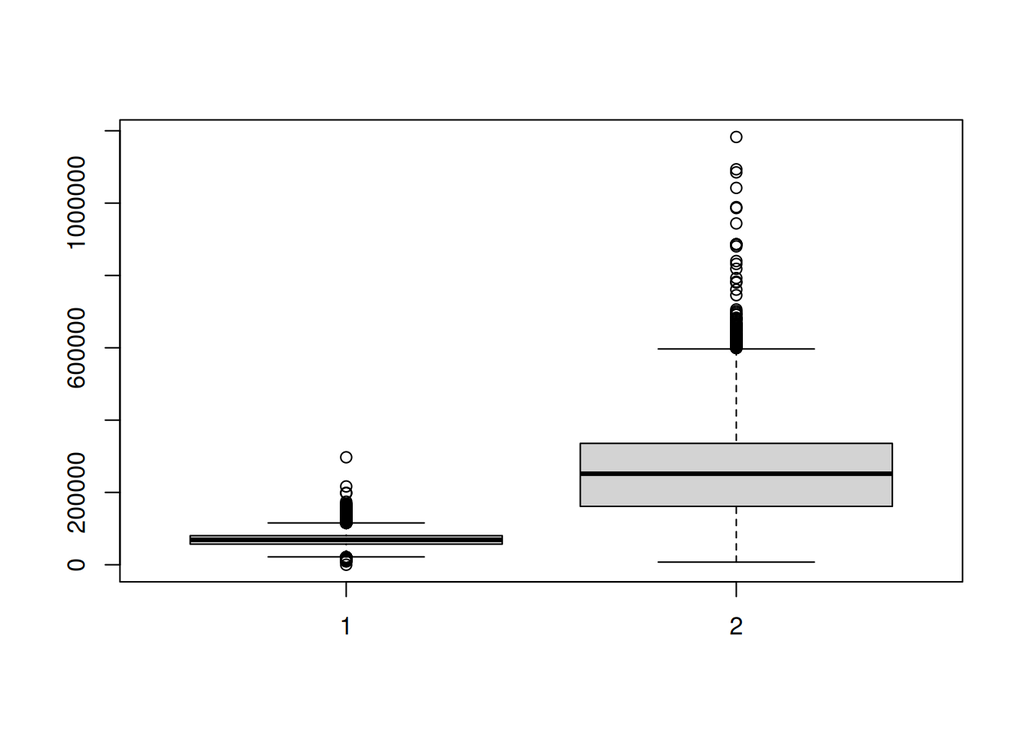

```r
boxplot(h$y1970, h$y2000) #make boxplot after scaling each
```

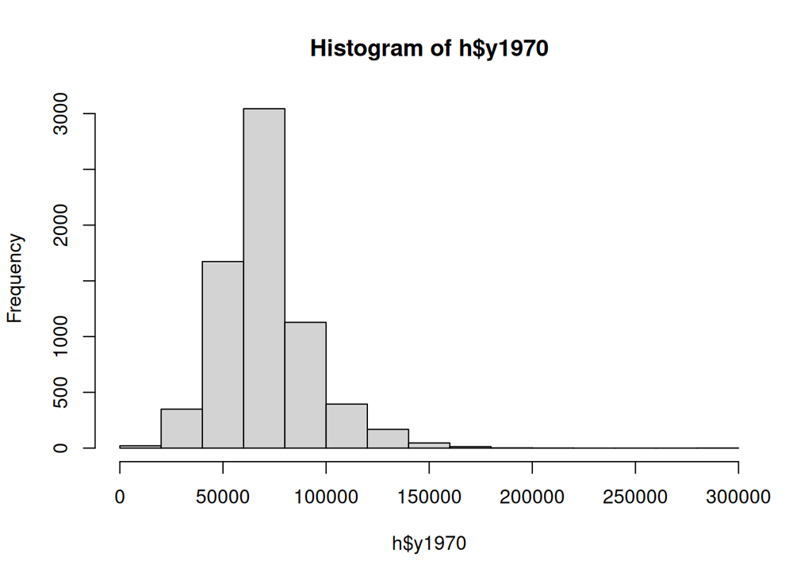

```r
hist(h$y1970)
```

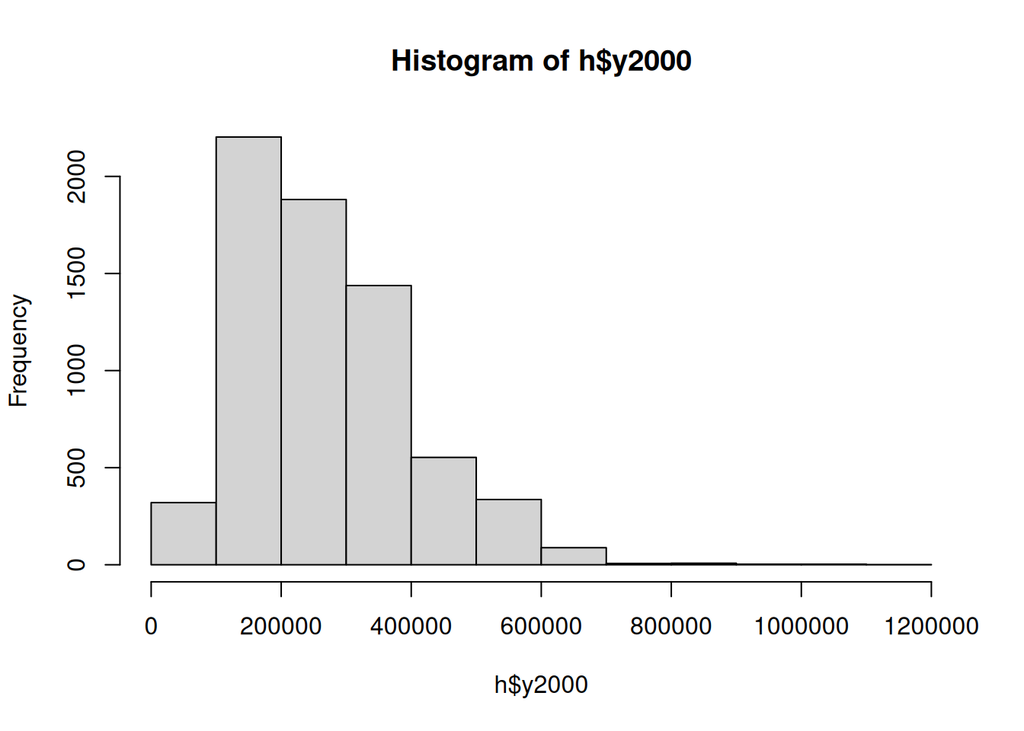

```r
hist(h$y2000)
```

We can see that the mean and variance has increased over time, and possibly the shape of the distribution has changed.

### Using scatterplots to compare relationships

Often we wish to investigate one numerical variable against another. For example the height of a father compared to their sons height. The plot command will gladly display two variables in a scatterplot.

#### Example: Home data

The home data example of the previous section shows old assessed value (1970) versus new assessed value (2000). There should be some relationship. Let’s investigate with a scatterplot (figure 12).

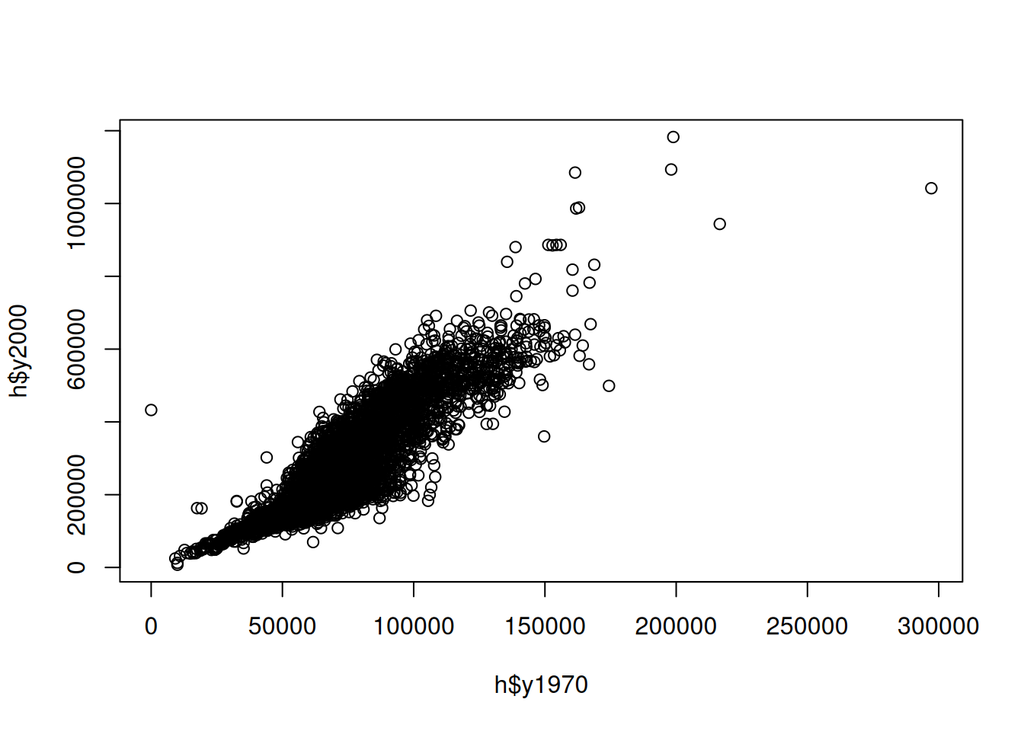

```r
plot(h$y1970, h$y2000)
```

We can improve the look of the scatter by playing around with the plotting symbol options, see eg (http://www.statmethods.net/advgraphs/parameters.html)

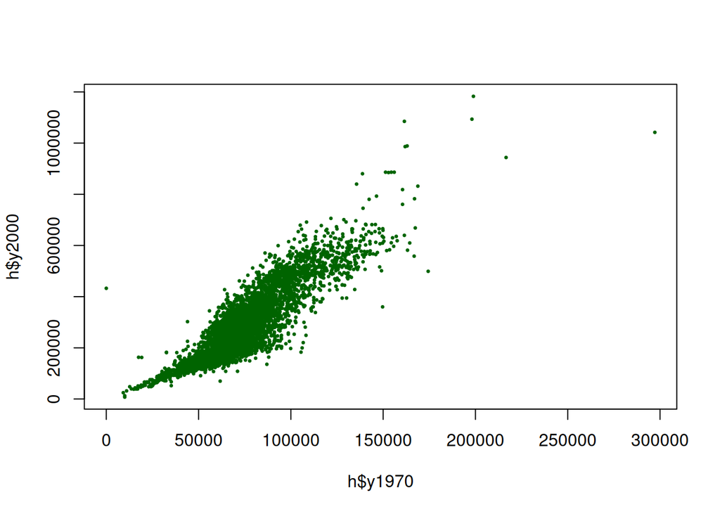

```r
plot(h$y1970, h$y2000, pch = 20, col = 'darkgreen', cex = 0.5)
```

and maybe add some other options (clearer labels, scale units, etc) to further improve the look

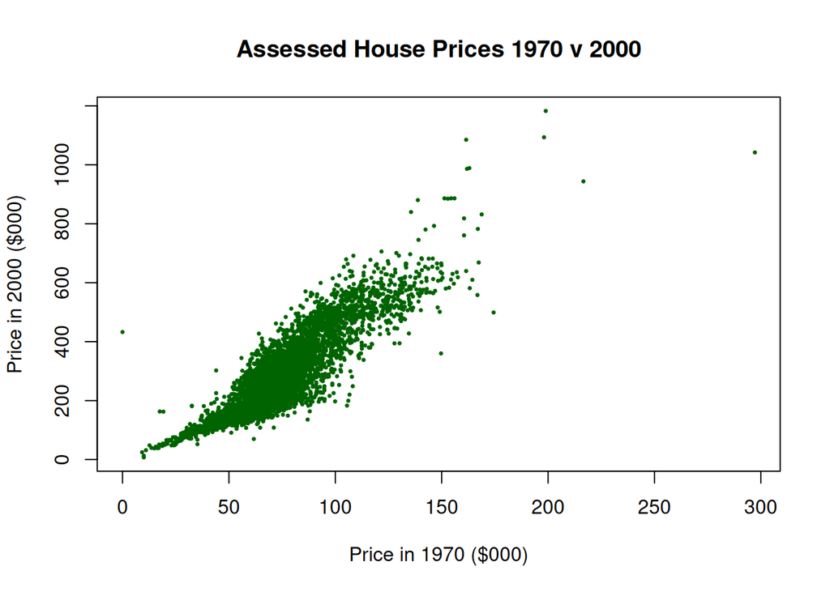

```r
plot(h$y1970/1000, h$y2000/1000, pch = 20, col = 'darkgreen',
     cex = 0.5, main = 'Assessed House Prices 1970 v 2000', xlab = 'Price in 1970 ($000)',
     ylab = 'Price in 2000 ($000)')
```

Figure 12: Scatterplot of home data

The graph seems to illustrate a strong and possibly linear trend.

#### Practice questions

Use a single line of R commands in each case to find out (answers given for checking, you supply the commands):

1. How many houses have fallen in price over this period ?

```
## [1] 1
```

2. In which row(s) of the data frame can we find these houses?

```
## [1] 2903
```

3. What was the price of this house (or these houses) in 1970, and in 2000?

```
##      y1970 y2000
## 2903 10000  7400
```

4. What was the largest increase in price over this period?

```
## [1] 983900
```

5. Plot a histogram of the price changes

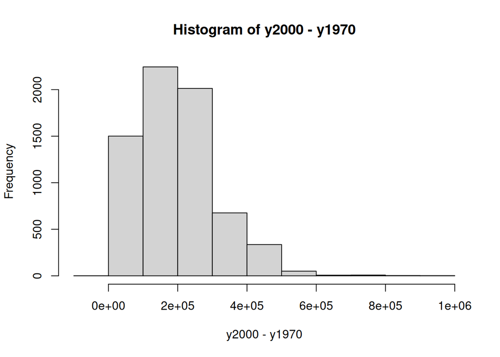